[O’Hara on GitHub](https://github.com/oharac)

# Calculate conservation priorities

Compiled on Thu Aug 22 15:41:28 2019 by ohara

```r
library(raster)
source('https://raw.githubusercontent.com/oharac/src/master/R/common.R')

source(here::here('common_fxns.R'))

dir_bd_anx <- '~/git-annex/bd_chi' ### this is on git-annex in home/ohara
dir_cons <- 'layers/cons_priorities'
```

# 1 Summary

Following Selig et al. 2014, estimate conservation priorities based on biodiversity metrics and threats.

- Identify top 10% and bottom 10% of cells based on cumulative impacts.
- Identify top 5% of cells based on species richness and range-rarity species richness, separately within EEZ and ABNJ.
- New: Identify top 5% and bottom 5% of cells based on mean biodiversity risk.
  - when intersecting with species richness, maybe up thresholds on both to 10%?
- New: Identify top 10% and bottom 10% of cells based on trends in CHI.
  - when intersecting with CHI, maybe up thresholds on both to 20%?

Intersect these various layers and see what magic occurs.

# 2 Data Sources

Halpern et al. 2019, O’Hara et al. 2019

# 3 Methods

## 3.1 Gather prepared rasters

The connservation priorities layers are all created prior to this script.

## 3.2 Basic analysis: impacts to biodiversity

To approximate Selig et al. 2014, compare the top 10% and bottom 10% of cumulative human impacts to the top 5% of species richness and top 5% of range-rarity-weighted species richness. We can also look at proportional range rarity, though this layer would need to be prepared here as it was not created for the BD risk project.

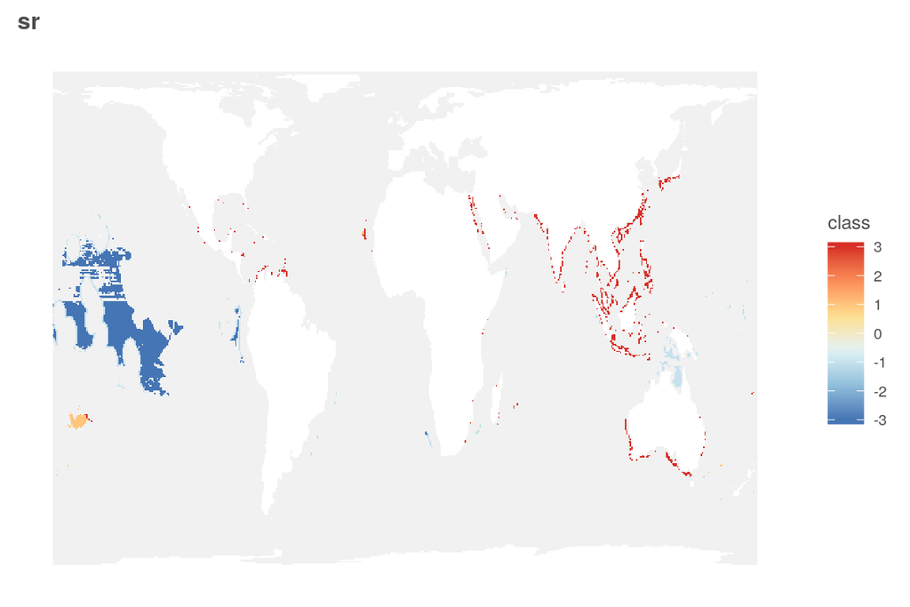

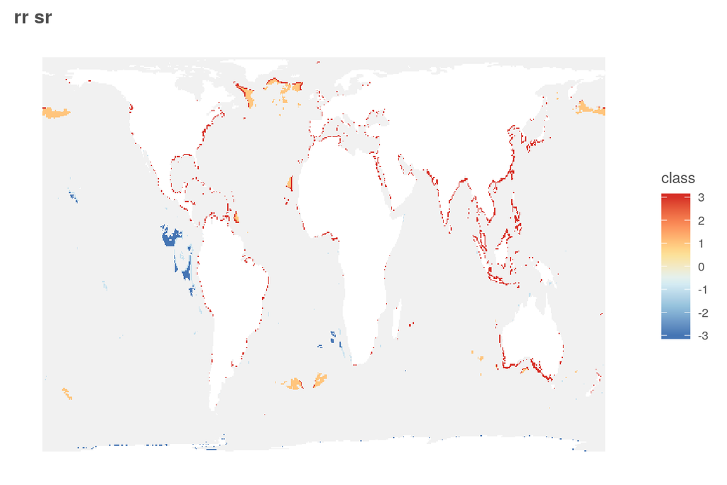